# Minicurso de Introdução ao R

# Estruturas de repetição

## For

Esse recurso pode ser a função `for`, uma função muito utilizada e poderosa. Ela constitui uma estrutura de loop, pois irá aplicar a mesma atividade repetidamente até atingir uma determinada condição. Veja exemplos:

```r
for(i in 1:10){
  print(i)
}
```

```
## [1] 1
## [1] 2
## [1] 3
## [1] 4
## [1] 5
## [1] 6
## [1] 7
## [1] 8
## [1] 9
## [1] 10
```

```r
test <- rep(0, times = 10)
for(i in 1:10){
  test[i] <- i*10
}
test
```

```
##  [1]  10  20  30  40  50  60  70  80  90 100
```

Nos casos acima, `i` funciona como um index que irá variar de 1 até 10 a operação determinada entre chaves.

Com essa estrutura, podemos repetir a operação realizada com as estruturas `if` e `else` para todo o vetor:

```r
for(i in 1:nrow(dados)){
  if(dados[i,5] < 1.5){
    print("Híbrido pequeno demais")
  } else if (dados[i,5] > 1.5 && dados[i,5] < 2.0){
    print("Tamanho OK")
  } else {
    print("Cresceu demais")
  }
}
```

```
## [1] "Híbrido pequeno demais"
## [1] "Híbrido pequeno demais"
## [1] "Híbrido pequeno demais"
## [1] "Híbrido pequeno demais"
## [1] "Cresceu demais"
## [1] "Híbrido pequeno demais"
## [1] "Híbrido pequeno demais"
## [1] "Cresceu demais"
## [1] "Cresceu demais"
## [1] "Híbrido pequeno demais"
## [1] "Híbrido pequeno demais"
## [1] "Tamanho OK"
## [1] "Híbrido pequeno demais"
## [1] "Cresceu demais"
## [1] "Híbrido pequeno demais"
```

[output cut: 185 more lines]

E assim, descobrir qual é a planta mais alta:

```r
maior_altura = max(dados[,5])

# Usando laço de repetição
for(i in 1:nrow(dados)){
  if(dados[i,5] == maior_altura){
    print(paste("A planta", i, "é a maior planta"))
  }
}
```

```
## [1] "A planta 8 é a maior planta"
```

```r
# Usando a função which
indice = which(dados[,5] == maior_altura)
print(paste("A planta", indice, "é a maior planta"))
```

```
## [1] "A planta 8 é a maior planta"
```

**Dica: Identação**

Repare a diferença:

```r
# Sem identação
for(i in 1:nrow(dados)){
if(dados[i,7] > mean(dados[,7]) + 3){
print("Esse híbrido tem muitas folhas")
} else if (dados[i,7] < mean(dados[,7]) - 3){
print("Esse híbrido tem poucas folhas")
} else {
print("Esse híbrido está perto da média")
}
}

# Com identação correta
for(i in 1:nrow(dados)){
  if(dados[i,7] > mean(dados[,7]) + 3){
    print("Esse híbrido tem muitas folhas")
  } else if (dados[i,7] < mean(dados[,7]) - 3){
    print("Esse híbrido tem poucas folhas")
  } else {
    print("Esse híbrido está perto da média")
  }
}
```

## Loops dentro de loops

É possível também utilizarmos estruturas de repetição dentro de estruturas de repetição. Por exemplo, se quisermos trabalhar tanto nas colunas como nas linhas de uma matrix.

```r
# Criando uma matrix vazia
ex_mat <- matrix(nrow=10, ncol=10)

# cada número dentro da matrix será o produto no índice da coluna pelo índice da linha
for(i in 1:dim(ex_mat)[1]) {
  for(j in 1:dim(ex_mat)[2]) {
    ex_mat[i,j] = i*j
  }
}

ex_mat
```

```
##       [,1] [,2] [,3] [,4] [,5] [,6] [,7] [,8] [,9] [,10]
##  [1,]    1    2    3    4    5    6    7    8    9    10
##  [2,]    2    4    6    8   10   12   14   16   18    20
##  [3,]    3    6    9   12   15   18   21   24   27    30
##  [4,]    4    8   12   16   20   24   28   32   36    40
##  [5,]    5   10   15   20   25   30   35   40   45    50
##  [6,]    6   12   18   24   30   36   42   48   54    60
##  [7,]    7   14   21   28   35   42   49   56   63    70
##  [8,]    8   16   24   32   40   48   56   64   72    80
##  [9,]    9   18   27   36   45   54   63   72   81    90
## [10,]   10   20   30   40   50   60   70   80   90   100
```

Fizemos um vídeo com mais detalhes sobre loops no R, aumentem nossa quantidade de views e likes por [lá](https://www.youtube.com/watch?v=VYOo7I5htOw).

> Faça os exercícios da **Sessão 3**

**Algumas dicas**:

- Cuidado ao rodar o mesmo comando mais de uma vez, algumas variáveis podem não ser mais como eram antes. Para que o comando funcione da mesma forma é necessário que os objetos de entrada estejam da forma como você espera.
- Lembrem-se que `=` é para definir objetos e `==` é o sinal de igualdade.
- Nas estruturas condicionais e de repetição, lembrem-se que é necessário manter a sintaxe esperada: If(){} e for(i in 1:10){}. No *for*, podemos trocar a letra que será o índice, mas é sempre necessário fornecer uma sequência de inteiros contínua.
- Usar identação ajuda a visualizar o começo e fim de cada estrutura de código e facilita o abrir e fechar de chaves. Identação são aqueles espaços que usamos antes da linha

# Elaboração de gráficos simples

Para outros dados coletados, vamos gerar alguns gráficos simples utilizando as funções básicas do R. Existem pacotes como o `ggplot2`, `plotly` e `shiny` que possuem ferramentas muito poderosas para construção de gráficos, mas exigem um pouco mais de tempo para aprendizagem de sua sintaxe.

Os tipos mais comuns já possuem funções próprias, mas outros gráficos podem ser customizados de acordo com a necessidade do usuário. Vamos iniciar com um simples gráfico de frequências (ou histograma) para os dados de `Altura`.

```r
hist(dados$AlturaPlantas)
```

Vamos adicionar alguns argumentos para dar uma personalizada:

- `breaks` para definir os intervalos para cada barra;

```r
#### Histograma ####
#Utiliza um vetor de valores para obter as frequências
hist(dados$AlturaPlantas)
hist(dados$AlturaPlantas, breaks = 2)
hist(dados$AlturaPlantas, breaks = 15)
```

Agora tente fazer o **histograma para o peso**, aproveite para tentar alterar alguns parâmetros.

Apresentaremos outros gráficos que poderão ser utilizados:

### Barplot

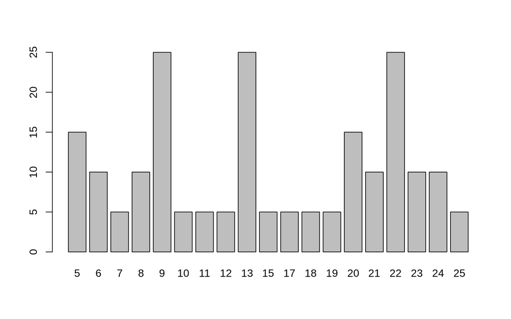

```r
#### Bar plot ####
#É um gráfico interessante quando possuímos resultados da função table
estande <- table(dados$Estande)
barplot(estande)
```

```r
#Alterando o eixo
barplot(estande, horiz = TRUE)

#Mais informações podem ser combinadas
nota_temp <- table(dados$Estande, dados$Tempo)
barplot(nota_temp)
```

### Curve

```r
#### Curve ####
#Utiliza uma expressão/função
curve(x^2 + 3*x)
curve(2*x, add = TRUE, col="red")
```

### Boxplot

```r
#### Boxplot ####
#Necessita de um vetor de valores ou uma expressão
boxplot(dados$AlturaPlantas)
boxplot(dados$AlturaPlantas~dados$Tempo)
```

[figure not shown]

### Scatter plot

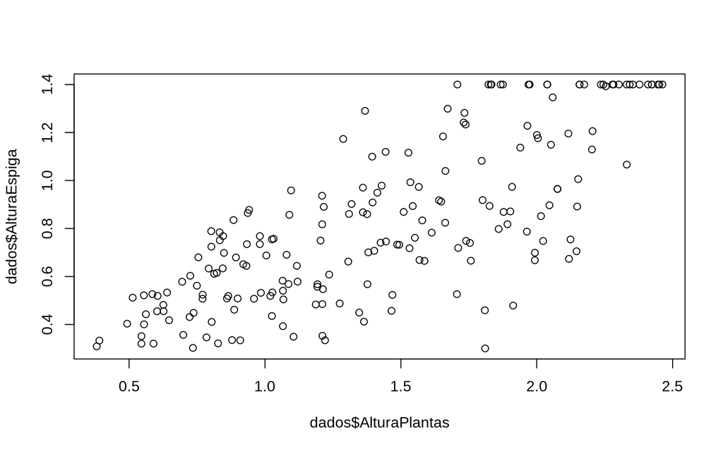

```r
#### Scatter plot ####
#Utilizaremos coordenadas de pontos.
plot(x = dados$AlturaPlantas, y= dados$AlturaEspiga)
```

## Parâmetros gráficos

É possível customizar os gráficos alterando seus eixos, cores, fontes, etc. Começaremos através do histograma:

- `col` para adicionar cor;
- `xlab` alterar título do eixo x;
- `ylab` alterar título do eixo y;
- `main` alterar título geral;

```r
hist(dados$NumeroFolhas, breaks=6, col="blue", xlab="Número de folhas",
     ylab="Frequencia", main="Histograma do número de Folhas")
```

Vamos explorar um pouco mais o gráfico de pontos. Vamos verificar se existe uma correlação entre o a altura de plantas e a altura da primeira espiga:

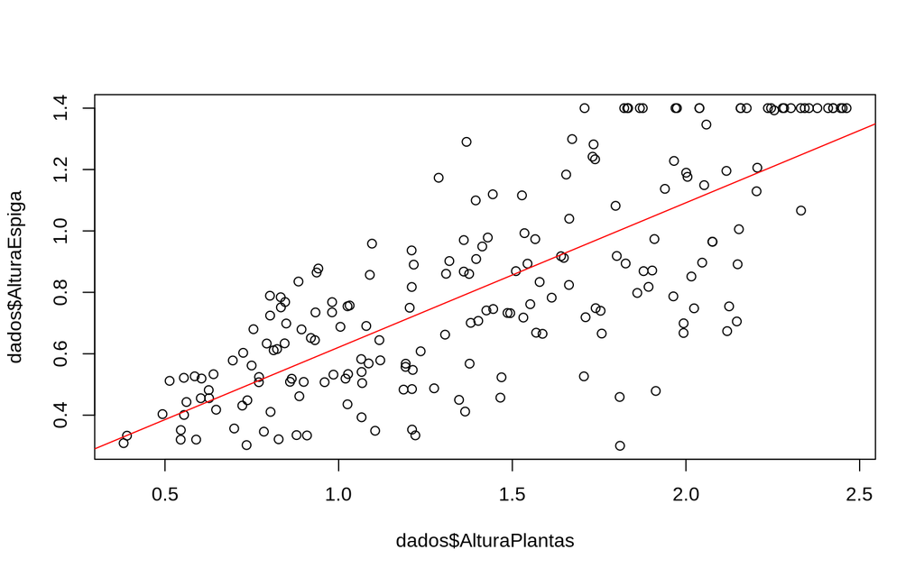

```r
#Busque explorar mais parâmetros no gráfico a seguir:
##Dica: tente alterar o nome dos eixos
plot(x = dados$AlturaPlantas, y= dados$AlturaEspiga)

#Linha de ajuste
abline(lm(AlturaEspiga ~ AlturaPlantas, data = dados), col="red")
```

```r
#Verificar a correlação:
cor(dados$AlturaPlantas, dados$AlturaEspiga)
```

```
## [1] 0.7678205
```

Alguns argumentos são específicos para cada função, busque mais informações sobre cada uma delas para entender sobre seus argumentos. Outros parâmetros gráficos mais recorrentes são os relacionados com:

- O tamanho de texto e símbolos, chamados de `cex`;
- Os símbolos de plotagem (25 ao todo), através do parâmetro `pch`;
- Há os relacionados com a fonte (`font` e `family`);
- Cores (`col`, `bg`, `fg`);

```r
#Tamanho, pontos e cores
plot(x = dados$AlturaPlantas, y= dados$AlturaEspiga,
     main = "Altura da prim. espiga  x Altura da planta", #Título principal
     xlab = "Altura de plantas", #Eixo x
     ylab = "Alturada prim. espiga", #Eixo y
     cex=2,
     cex.axis=1.5)
```

Agora, busque alterar o nome dos rótulos (lab) e do título (main). Também utilize o parâmetro ‘pch=’ e coloque um número de 0 a 25.

De maneira similar ao tamanho, tente alterar as cores (utilize o color() para ver todas as cores disponíveis).

## Salvar gráficos

Os gráficos podem ser salvos através dos menus disponíveis no RStudio, ou através de funções que permitem salvar em formatos específicos. Algumas delas são: pdf(); png(); jpeg(); bitmap(). De maneira geral, o parâmetro primordial é fornecer o nome do arquivo que será gerado (contendo sua extensão). Após abrir a função gráfica, deve-se gerar o gráfico de interesse. Por fim, utiliza-se o comando dev.off() para que saída gráfica volte para o console.

```r
png(filename = "grafico_pontos.png")
plot(x = dados$AlturaPlantas, y= dados$AlturaEspiga,
     main = "Altura da prim. espiga  x Altura da planta", #Título principal
     xlab = "Altura de plantas", #Eixo x
     ylab = "Alturada prim. espiga", #Eixo y
     cex=2,
     cex.axis=1.5)
dev.off()

png(filename = "grafico_pontos.png", width = 1500, height = 1500, res= 300)
plot(x = dados$AlturaPlantas, y= dados$AlturaEspiga,
     main = "Altura da prim. espiga  x Altura da planta", #Título principal
     xlab = "Altura de plantas", #Eixo x
     ylab = "Alturada prim. espiga", #Eixo y
     cex=2,
     cex.axis=1.5)
dev.off()
```

Gere um gráfico e salve-o no formato de seu interesse. Em seguida, crie diversos gráficos dentro de uma mesma função gráfica e estude a saída.

Paramos aqui na parte da manhã do segundo dia do treinamento.

- Caso não tenha salvado os objetos criados até agora, obtenha-os [aqui](https://GENt-esalq.github.io/XIII_GMP/dia2.1.RData).
- [Aqui](https://GENt-esalq.github.io/XIII_GMP/dia2.1.R) você pode acessar um exemplo de script `.R`.
- E [aqui](https://GENt-esalq.github.io/XIII_GMP/dia2.1.Rmd) um exemplo de arquivo `.Rmd` para gerar um relatório com o conteúdo até agora. E suas versões compiladas em pdf e html.

# Instalação e aplicações de pacotes

O que deixa o R ainda mais poderoso é a capacidade de incorporármos à ele novas funções chamando pacotes. Existem milhares de pacotes disponíveis no CRAN (repositorio oficial), e outros repositórios. Para cada área de estudo existem diversos pacotes disponíveis. Aqui usaremos o pacote `desplot`.

Como ele esta disponível no CRAN, para instalá-lo basta:

```r
install.packages("desplot")
```

Depois disso é necessário recrutá-lo com:

```r
library(desplot) # Este comando será necessário toda vez que for utilizar o pacote
```

Este pacote é um conjunto de funções elaboradas para gerar gráficos de campo. Você pode obter mais informações sobre ele no [manual disponível no CRAN](https://cran.r-project.org/web/packages/desplot/index.html).

Com esse pacote podemos desenhar o experimento de campo (assim como esta no papel que recebeu, mas um pouco mais bonito).

Para isso vamos adicionar duas outras colunas no nossa data.frame, com informações da posição de cada indivíduo no campo.

```r
row <- rep(rep(1:10, each=5),4)
col <- c(rep(1:5,10),rep(6:10,10), rep(11:15,10), rep(16:20,10))
dados.up <- cbind(col, row, dados)
```

Para usar a função do pacote, buscamos no google por tutoriais, [aqui](https://cran.r-project.org/web/packages/desplot/vignettes/desplot_examples.html) esta aquele no qual nos baseamos para elaborarmos o código abaixo.

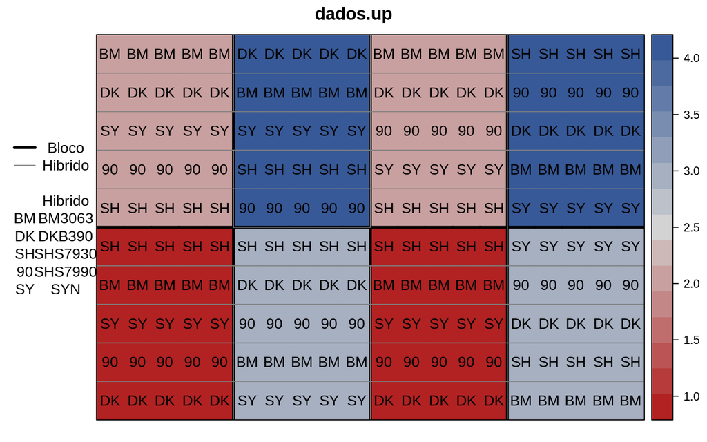

```r
desplot(Bloco ~ col+row, dados.up,
        text=Hibrido, cex=1, out1=Bloco,
        out2=Hibrido, out2.gpar=list(col = "gray50", lwd = 1, lty = 1))
```

Paramos aqui na primeira parte da manhã de sábado (18.05) e seguimos para uma parte específica da sessão **Algumas Ferramentas de Análise de dados**, clique aqui para ir até lá.

# Algumas ferramentas básicas de análise de dados

Claramente a análise de dados é algo muito específico de cada conjunto de dados e interesses. Vamos aqui mostrar alguns recursos básicos como análise de variância, regressão e teste de médias.

Algumas avaliações descritivas podem ser feitas pelo uso do `tapply` e de gráficos. A função `summary` também da informações gerais do conjunto. É possível usá-la em conjunto com o `tapply`.

```r
str(dados)
```

```
## 'data.frame':    200 obs. of  8 variables:
##  $ Tempo        : chr  "T1" "T1" "T1" "T1" ...
##  $ Bloco        : int  1 1 1 1 1 1 1 1 1 1 ...
##  $ Parcela      : int  1 1 1 1 1 2 2 2 2 2 ...
##  $ Hibrido      : chr  "DKB390" "DKB390" "DKB390" "DKB390" ...
##  $ AlturaPlantas: num  0.513 1.486 1.36 1.096 2.175 ...
##  $ AlturaEspiga : num  0.512 0.733 0.868 0.959 1.4 ...
##  $ NumeroFolhas : int  17 10 9 24 21 14 16 20 12 15 ...
##  $ Estande      : int  9 9 9 9 9 5 5 5 5 5 ...
```

```r
# Certifique-se que esta lidando com variável categórica (fator)
dados$Hibrido <- as.factor(dados$Hibrido)
dados$Parcela <- as.factor(dados$Parcela)
dados$Bloco <- as.factor(dados$Bloco)

tapply(dados$AlturaPlantas, dados$Hibrido, summary)
```

```
## $BM3063
##    Min. 1st Qu.  Median    Mean 3rd Qu.    Max.
##  0.4929  0.9329  1.4040  1.3996  1.8430  2.3419
##
## $DKB390
##    Min. 1st Qu.  Median    Mean 3rd Qu.    Max.
##  0.5132  1.1119  1.5433  1.4890  1.8617  2.4237
##
## $SHS7930
##    Min. 1st Qu.  Median    Mean 3rd Qu.    Max.
##  0.3809  0.9758  1.2814  1.2729  1.5612  2.4457
##
## $SHS7990
##    Min. 1st Qu.  Median    Mean 3rd Qu.    Max.
##  0.5456  0.8821  1.6916  1.5421  2.0092  2.4624
##
## $SYN
##    Min. 1st Qu.  Median    Mean 3rd Qu.    Max.
##  0.5543  0.8783  1.3395  1.4064  1.9231  2.4238
```

```r
tapply(dados$AlturaEspiga, dados$Hibrido, summary)
```

```
## $BM3063
##    Min. 1st Qu.  Median    Mean 3rd Qu.    Max.
##  0.3215  0.6278  0.7787  0.8694  1.2127  1.4000
##
## $DKB390
##    Min. 1st Qu.  Median    Mean 3rd Qu.    Max.
##  0.3025  0.5228  0.7581  0.8311  1.0788  1.4000
##
## $SHS7930
##    Min. 1st Qu.  Median    Mean 3rd Qu.    Max.
##  0.3089  0.5024  0.6988  0.7513  0.9179  1.4000
##
## $SHS7990
##    Min. 1st Qu.  Median    Mean 3rd Qu.    Max.
##  0.3515  0.6034  0.7495  0.8787  1.1905  1.4000
##
## $SYN
##    Min. 1st Qu.  Median    Mean 3rd Qu.    Max.
##  0.3003  0.5240  0.7447  0.7685  0.9184  1.4000
```

Qual a relaçao linear entre altura de plantas e altura da primeira espiga?

```r
mod1 <- lm(AlturaPlantas ~ AlturaEspiga, data = dados)
summary(mod1)
```

```
##
## Call:
## lm(formula = AlturaPlantas ~ AlturaEspiga, data = dados)
##
## Residuals:
##      Min       1Q   Median       3Q      Max
## -0.64267 -0.29175 -0.02413  0.23616  1.03856
##
## Coefficients:
##              Estimate Std. Error t value Pr(>|t|)
## (Intercept)   0.39565    0.06585   6.009 8.83e-09 ***
## AlturaEspiga  1.25196    0.07424  16.864  < 2e-16 ***
## ---
## Signif. codes:  0 '***' 0.001 '**' 0.01 '*' 0.05 '.' 0.1 ' ' 1
##
## Residual standard error: 0.3554 on 198 degrees of freedom
## Multiple R-squared:  0.5895, Adjusted R-squared:  0.5875
## F-statistic: 284.4 on 1 and 198 DF,  p-value: < 2.2e-16
```

Podemos falar que a altura de plantas é significativamente diferente entre hibridos?

```r
mod1 <- aov(AlturaPlantas ~ Hibrido + Tempo:Bloco + Tempo:Bloco:Parcela, data = dados)
summary(mod1)
```

```
##                      Df Sum Sq Mean Sq F value Pr(>F)
## Hibrido               4   1.68  0.4190   1.414  0.232
## Tempo:Bloco           7   2.33  0.3333   1.125  0.350
## Tempo:Bloco:Parcela  28   9.52  0.3400   1.147  0.292
## Residuals           160  47.41  0.2963
```

O p-valor nos indica se podemos considerar diferenças de altura conforme o híbrido. Podemos também fazer um teste de médias para diferenciar a altura de plantas de cada híbrido. Aqui utilizaremos o método de Tukey:

```r
modaov <- aov(AlturaPlantas ~ Hibrido + Tempo:Bloco + Tempo:Bloco:Parcela, data = dados)
tukey.test <- TukeyHSD(x=modaov, 'Hibrido', conf.level=0.95)
tukey.test
```

```
##   Tukey multiple comparisons of means
##     95% family-wise confidence level
##
## Fit: aov(formula = AlturaPlantas ~ Hibrido + Tempo:Bloco + Tempo:Bloco:Parcela, data = dados)
##
## $Hibrido
##                         diff         lwr       upr     p adj
## DKB390-BM3063    0.089393187 -0.24645617 0.4252425 0.9481522
## SHS7930-BM3063  -0.126766566 -0.46261592 0.2090828 0.8356790
## SHS7990-BM3063   0.142456832 -0.19339252 0.4783062 0.7682548
## SYN-BM3063       0.006779435 -0.32906992 0.3426288 0.9999978
## SHS7930-DKB390  -0.216159754 -0.55200911 0.1196896 0.3912733
## SHS7990-DKB390   0.053063645 -0.28278571 0.3889130 0.9924298
## SYN-DKB390      -0.082613752 -0.41846311 0.2532356 0.9607890
## SHS7990-SHS7930  0.269223398 -0.06662596 0.6050728 0.1806541
## SYN-SHS7930      0.133546002 -0.20230335 0.4693954 0.8078109
## SYN-SHS7990     -0.135677397 -0.47152675 0.2001720 0.7986372
```

Podemos obter mais informações sobre o modelo ajustado observando os gráficos:

```r
plot(mod1)
```

## Experimento de café

Agora, vamos trabalhar com outro conjunto de dados, contendo informações de um experimento de café. Acesse aqui:

- Arquivo cafe.txt

O experimento trata-se de dados em blocos completos casualizados de 10 progênies de café. Nele contém uma coluna rep para especificar a qual repetição o dado se refere, outra para qual indivíduo da progênie (prog) e outra para indicar em qual colheita o dado foi retirado (colheita).

```r
data <- read.table("cafe.txt", h = TRUE, sep = "\t", dec = ",")
str(data)
```

```
## 'data.frame':    120 obs. of  4 variables:
##  $ rep     : int  1 1 1 1 1 1 1 1 1 1 ...
##  $ prog    : int  1 2 3 4 5 6 7 8 9 10 ...
##  $ colheita: int  1 1 1 1 1 1 1 1 1 1 ...
##  $ prod    : num  4.3 13.2 1.59 2.76 11.38 ...
```

Não esqueça que é necessário que o arquivo esteja no seu ambiente de trabalho ou que você especifique o caminho completo para que o R o encontre.

Para essa análise de dados, nossa variável resposta é a produção (prod), a repetição (rep), a progênie (prog) e a colheita serão fatores no nosso modelo, identificados por seus níveis.

```r
# Transformar em fator
data$rep <- as.factor(data$rep)
data$prog <- as.factor(data$prog)
data$colheita <- as.factor(data$colheita)
str(data)
```

```
## 'data.frame':    120 obs. of  4 variables:
##  $ rep     : Factor w/ 4 levels "1","2","3","4": 1 1 1 1 1 1 1 1 1 1 ...
##  $ prog    : Factor w/ 10 levels "1","2","3","4",..: 1 2 3 4 5 6 7 8 9 10 ...
##  $ colheita: Factor w/ 3 levels "1","2","3": 1 1 1 1 1 1 1 1 1 1 ...
##  $ prod    : num  4.3 13.2 1.59 2.76 11.38 ...
```

```r
# Outra opção
data <- transform(data, rep = factor(rep), prog = factor(prog), colheita = factor(colheita))
str(data)
```

```
## 'data.frame':    120 obs. of  4 variables:
##  $ rep     : Factor w/ 4 levels "1","2","3","4": 1 1 1 1 1 1 1 1 1 1 ...
##  $ prog    : Factor w/ 10 levels "1","2","3","4",..: 1 2 3 4 5 6 7 8 9 10 ...
##  $ colheita: Factor w/ 3 levels "1","2","3": 1 1 1 1 1 1 1 1 1 1 ...
##  $ prod    : num  4.3 13.2 1.59 2.76 11.38 ...
```

Vamos primeiro análisar somente os dados referentes à primeira colheira. Podemos fazer um subset somente com esses dados.

```r
# Indexar primeita colheita
Colheita_1 <- subset(data, colheita == 1)
str(Colheita_1)
```

```
## 'data.frame':    40 obs. of  4 variables:
##  $ rep     : Factor w/ 4 levels "1","2","3","4": 1 1 1 1 1 1 1 1 1 1 ...
##  $ prog    : Factor w/ 10 levels "1","2","3","4",..: 1 2 3 4 5 6 7 8 9 10 ...
##  $ colheita: Factor w/ 3 levels "1","2","3": 1 1 1 1 1 1 1 1 1 1 ...
##  $ prod    : num  4.3 13.2 1.59 2.76 11.38 ...
```

Repare que, ao fazer o subset, o conjunto de dados ainda mantém os três níveis do fator colheira, embora agora só tenhamos um. Isso pode ser um problema para a nossa análise, vamos remover os níveis excedentes com:

```r
# Droplevels
Colheita_1 <- droplevels(subset(data, colheita == 1))
str(Colheita_1)
```

```
## 'data.frame':    40 obs. of  4 variables:
##  $ rep     : Factor w/ 4 levels "1","2","3","4": 1 1 1 1 1 1 1 1 1 1 ...
##  $ prog    : Factor w/ 10 levels "1","2","3","4",..: 1 2 3 4 5 6 7 8 9 10 ...
##  $ colheita: Factor w/ 1 level "1": 1 1 1 1 1 1 1 1 1 1 ...
##  $ prod    : num  4.3 13.2 1.59 2.76 11.38 ...
```

Agora podemos rodar nosso modelo de análise de variância.

```r
# Modelo
Modelo1 <- aov(prod ~ rep + prog,
               contrasts = list(prog = "contr.sum"),
               data = Colheita_1)
anova(Modelo1)
```

```
## Analysis of Variance Table
##
## Response: prod
##           Df Sum Sq Mean Sq F value   Pr(>F)
## rep        3  58.90  19.633  2.1836 0.113071
## prog       9 410.32  45.591  5.0708 0.000475 ***
## Residuals 27 242.75   8.991
## ---
## Signif. codes:  0 '***' 0.001 '**' 0.01 '*' 0.05 '.' 0.1 ' ' 1
```

Essa análise variância exige alguns pressupostos, podemos verificar eles nos nossos dados usando:

```r
####################################################
###verificar Pressupostos da análise de variância###
####################################################
names(Modelo1)
```

```
##  [1] "coefficients"  "residuals"     "effects"       "rank"
##  [5] "fitted.values" "assign"        "qr"            "df.residual"
##  [9] "contrasts"     "xlevels"       "call"          "terms"
## [13] "model"
```

```r
Modelo1_residuals <- Modelo1$residuals #armazenando os erros ou resíduos

# teste de Normalidade DOS ERROS##
#---------------------------------#
shapiro.test (Modelo1_residuals) # Hipótese de Nulidade
```

```
##
##  Shapiro-Wilk normality test
##
## data:  Modelo1_residuals
## W = 0.96494, p-value = 0.2461
```

```r
# a hipótese de que os erros são normais, nesse caso, como o p-value = 0.24
# ou seja, >0.05 ou 0.01 ou qualquer alfa adotado, não se rejeita a hipotese de normalidade
```

Agora, vamos precisar de funções contidas nos scripts `DIAGNOSTICS.R` e `"outliers.R"`. Acesse eles em:

- DIAGNOSTICS.R
- outliers.R

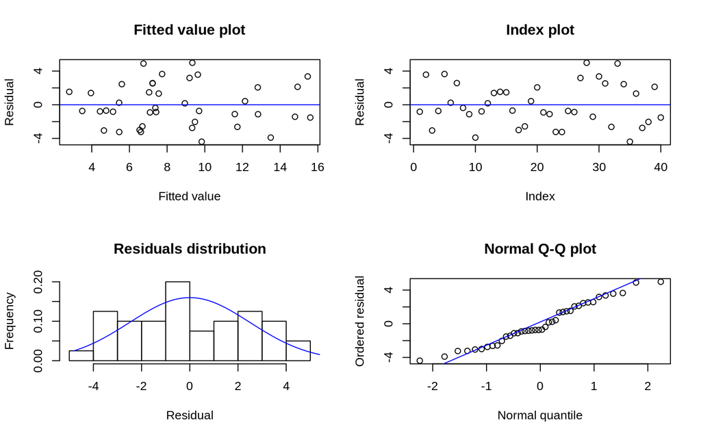

```r
# Funções
source("DIAGNOSTICS.R")
source("outliers.R")


#Verificar pressupostos de análises
diagnostics(Modelo1$residuals, Modelo1$fitted.values)
```

As vezes outliers podem ser difíceis de identificarmos, aqui esta uma função (detalhes sobre a identificação e remoção de outliers estão disponíveis no artigo Bernal-Vasquez, AM., Utz, HF. & Piepho, HP. Theor Appl Genet-2016) que pode fazer isso:

```r
# Verificar outlier
outlier(Modelo1$residuals, alpha=0.05)
```

```
## No outlier detected
```

```
## numeric(0)
```

Guardando o valor do quadrado médio:

```r
QME <- anova(Modelo1)["Residuals", "Mean Sq"]
QME
```

```
## [1] 8.990907
```

E a média da primeira colheita da nossa variavel resposta (produção):

```r
med <- mean(Colheita_1$prod, na.rm = TRUE)
med
```

```
## [1] 8.54525
```

Com eles podemos calcular o coeficiente de variação (CV):

```r
CVe <- (sqrt(QME)/med)*100
CVe
```

```
## [1] 35.08948
```

> Calcule o CVe e QME para a colheita 2

> Crie uma função calcular o CVe

Possibilidade de respostas:

```r
CV_E <- function(anova, med){
  QME <- anova(anova)["Residuals", "Mean Sq"]
  CVe <- (sqrt(QME)/med)*100

  return(CVe)
}

##
CV_E(anova = Modelo1, med = med)
```

```
## [1] 35.08948
```

Podemos também calcular a herdabilidade da característica produção:

```r
n_rep <- nlevels(Colheita_1$rep)
VG <- (anova(Modelo1)["prog", "Mean Sq"]- QME)/n_rep
VE <- QME
H_2 <- VG/ (VG + VE)
H_2
```

```
## [1] 0.5043871
```

> Crie uma função para estimar a herdabilidade

Agora faremos um teste de comparações múltiplas utilizando a análise de variância feita no pacote `ExpDes`.

```r
#install.packages("ExpDes")
library(ExpDes)

# Teste de Tukey
rbd(Colheita_1$prog, Colheita_1$rep, Colheita_1$prod, mcomp = "tukey", sigT = 0.05, sigF = 0.05)
```

```
## ------------------------------------------------------------------------
## Analysis of Variance Table
## ------------------------------------------------------------------------
##            DF     SS     MS     Fc    Pr>Fc
## Treatament  9 410.32 45.591 5.0708 0.000475
## Block       3  58.90 19.633 2.1836 0.113071
## Residuals  27 242.75  8.991
## Total      39 711.97
## ------------------------------------------------------------------------
## CV = 35.09 %
##
## ------------------------------------------------------------------------
## Shapiro-Wilk normality test
## p-value:  0.2460709
## According to Shapiro-Wilk normality test at 5% of significance, residuals can be considered normal.
## ------------------------------------------------------------------------
##
## ------------------------------------------------------------------------
## Homogeneity of variances test
## p-value:  0.2852398
## According to the test of oneillmathews at 5% of significance, the variances can be considered homocedastic.
## ------------------------------------------------------------------------
##
## Tukey's test
## ------------------------------------------------------------------------
## Groups Treatments Means
## a     10      14.3425
## a     9   13.6675
## ab    2   10.4725
## ab    5   8.5775
## ab    8   8.22
## ab    7   8.0725
##  b    6   6.2975
##  b    1   5.9725
##  b    3   5.49
##  b    4   4.34
## ------------------------------------------------------------------------
```

```r
# Teste de agrupamento de Scot- Knott
rbd(Colheita_1$prog, Colheita_1$rep, Colheita_1$prod, mcomp = "sk", sigT = 0.05, sigF = 0.05)
```

```
## ------------------------------------------------------------------------
## Analysis of Variance Table
## ------------------------------------------------------------------------
##            DF     SS     MS     Fc    Pr>Fc
## Treatament  9 410.32 45.591 5.0708 0.000475
## Block       3  58.90 19.633 2.1836 0.113071
## Residuals  27 242.75  8.991
## Total      39 711.97
## ------------------------------------------------------------------------
## CV = 35.09 %
##
## ------------------------------------------------------------------------
## Shapiro-Wilk normality test
## p-value:  0.2460709
## According to Shapiro-Wilk normality test at 5% of significance, residuals can be considered normal.
## ------------------------------------------------------------------------
##
## ------------------------------------------------------------------------
## Homogeneity of variances test
## p-value:  0.2852398
## According to the test of oneillmathews at 5% of significance, the variances can be considered homocedastic.
## ------------------------------------------------------------------------
##
## Scott-Knott test
## ------------------------------------------------------------------------
##    Groups Treatments   Means
## 1       a         10 14.3425
## 2       a          9 13.6675
## 3       a          2 10.4725
## 4       b          5  8.5775
## 5       b          8  8.2200
## 6       b          7  8.0725
## 7       b          6  6.2975
## 8       b          1  5.9725
## 9       b          3  5.4900
## 10      b          4  4.3400
## ------------------------------------------------------------------------
```

Agora vamos apresentar outras opções para analisarmos cada colheita individualmente.

```r
# função by é similar ao subset
by(data, data$colheita, function (x) anova(aov(prod ~ prog + rep, data= x)))
```

```
## data$colheita: 1
## Analysis of Variance Table
##
## Response: prod
##           Df Sum Sq Mean Sq F value   Pr(>F)
## prog       9 410.32  45.591  5.0708 0.000475 ***
## rep        3  58.90  19.633  2.1836 0.113071
## Residuals 27 242.75   8.991
## ---
## Signif. codes:  0 '***' 0.001 '**' 0.01 '*' 0.05 '.' 0.1 ' ' 1
## --------------------------------------------------------
## data$colheita: 2
## Analysis of Variance Table
##
## Response: prod
##           Df  Sum Sq Mean Sq F value  Pr(>F)
## prog       9 143.327 15.9253  3.0702 0.01147 *
## rep        3  12.757  4.2524  0.8198 0.49430
## Residuals 27 140.049  5.1870
## ---
## Signif. codes:  0 '***' 0.001 '**' 0.01 '*' 0.05 '.' 0.1 ' ' 1
## --------------------------------------------------------
## data$colheita: 3
## Analysis of Variance Table
##
## Response: prod
##           Df  Sum Sq Mean Sq F value  Pr(>F)
## prog       9 307.340  34.149  2.9481 0.01421 *
## rep        3   9.104   3.035  0.2620 0.85213
## Residuals 27 312.752  11.583
## ---
## Signif. codes:  0 '***' 0.001 '**' 0.01 '*' 0.05 '.' 0.1 ' ' 1
```

```r
#verificar os graus de liberdade, cuidado para que sejam utilizados de fato os dados de apenas 1 colheita


#outra opção selecionando apenas a parte da dataframe onde colheita igual a "2"
anova(aov(data$prod ~ data$prog + data$rep, data = data[data$colheita==2,]))
```

```
## Analysis of Variance Table
##
## Response: data$prod
##            Df  Sum Sq Mean Sq F value  Pr(>F)
## data$prog   9  293.00  32.556  2.5748 0.01007 *
## data$rep    3   44.42  14.808  1.1711 0.32428
## Residuals 107 1352.91  12.644
## ---
## Signif. codes:  0 '***' 0.001 '**' 0.01 '*' 0.05 '.' 0.1 ' ' 1
```

```r
# mais uma opção com o uso da família apply
indiv <- lapply(split(data, data$colheita), aov, formula = prod ~ rep + prog)
lapply(indiv, summary)
```

```
## $`1`
##             Df Sum Sq Mean Sq F value   Pr(>F)
## rep          3   58.9   19.63   2.184 0.113071
## prog         9  410.3   45.59   5.071 0.000475 ***
## Residuals   27  242.8    8.99
## ---
## Signif. codes:  0 '***' 0.001 '**' 0.01 '*' 0.05 '.' 0.1 ' ' 1
##
## $`2`
##             Df Sum Sq Mean Sq F value Pr(>F)
## rep          3  12.76   4.252    0.82 0.4943
## prog         9 143.33  15.925    3.07 0.0115 *
## Residuals   27 140.05   5.187
## ---
## Signif. codes:  0 '***' 0.001 '**' 0.01 '*' 0.05 '.' 0.1 ' ' 1
##
## $`3`
##             Df Sum Sq Mean Sq F value Pr(>F)
## rep          3    9.1    3.03   0.262 0.8521
## prog         9  307.3   34.15   2.948 0.0142 *
## Residuals   27  312.8   11.58
## ---
## Signif. codes:  0 '***' 0.001 '**' 0.01 '*' 0.05 '.' 0.1 ' ' 1
```

Agora, com o pacote `agricolae` elaboraremos o sorteio de um experimento também de blocos completos casualizados.

```r
############################
#SORTEIO DE EXPERIMENTOS####
############################

#install.packages("agricolae")
library(agricolae)
trt <- c("0","1","2","5","10","20","50","100","Dina")
rcbd <- design.rcbd(trt, 6, serie = 1, seed = 1, "default") # seed = 1
rcbd # Planilha de campo
```

```
## $parameters
## $parameters$design
## [1] "rcbd"
##
## $parameters$trt
## [1] "0"    "1"    "2"    "5"    "10"   "20"   "50"   "100"  "Dina"
##
## $parameters$r
## [1] 6
##
## $parameters$serie
## [1] 1
##
## $parameters$seed
## [1] 1
```

[output cut: 73 more lines]

Podemos exportar e salvar nosso sorteio com:

```r
write.table(rcbd,"SORTEIO.txt", row.names=FALSE, sep="\t")
file.show("SORTEIO.txt")
write.csv(rcbd,"SORTEIO.csv",row.names=F)
```

# Feedback e outros materiais

Caso tenha sugestões para aprimoramento desse material, enviar e-mail para `gent.esalq@gmail.com`.

Acesse também outros materiais em português produzidos por Cristiane Taniguti, Fernando Correr e Rodrigo Amadeu [aqui](http://cristianetaniguti.github.io/Workshop_genetica_esalq/).

Este material foi produzido por alunos do programa de pós-graduação em Genética e Melhoramento de Plantas. Ana Letycia Basso Garcia, Cristiane Taniguti, Fernando Correr, Guilherme Hokasa e Victor Mello ministraram o Treinamento.

Também recomendamos materiais em inglês [aqui](https://GENt-esalq.github.io/XIII_GMP/english_tutorials.html).

[GENt](https://gent-esalq.github.io/)  
Escola Superior de Agricultura Luiz de Queiroz  
Universidade de São Paulo

2019-07-19